# NHS App Utilisation

Author

[Andy Wilson](https://github.com/ASW-Analyst/)  
[Molly Glynn](https://www.linkedin.com/in/molly-glynn/)  
[NHS Transformation Unit](https://transformationunit.nhs.uk/)

Published

20 October 2025

[figure not shown]

**Executive Summary**

The NHS App (hereafter referred to as ‘the App’) is central to England’s 10-Year Health Plan, with ambitions to collect actionable patient feedback by 2028. Ensuring that feedback reflects the full diversity of NHS service users is critical to addressing health inequalities. The Transformation Unit’s (TU) recent analysis of App usage data, obtained via a Freedom of Information request, shows significant variation across age groups and regions. Key findings include:

- **Older adults are notably underrepresented** relative to their share of outpatient activity.
- While usage of the App is higher in more deprived areas, this **could be confounded by younger populations** living in those areas.
- Currently utilisation data of the App **can’t be linked to information on gender and ethnicity**, though NHS England (NHSE) is working to improve demographic linkage by winter 2025.

Going forward, NHSE must prioritise better data linkage and transparency to ensure feedback is representative and equitable. With the abolition of Healthwatch England and the shift of engagement responsibilities to Integrated Care Boards (ICBs) and providers, there is a risk that seldom-heard groups lose their collective voices. Clear accountability for App engagement, particularly the future of NHS App Ambassadors, must be established. All data and code used in this analysis are publicly available via the associated [Github repository](https://github.com/NHS-Transformation-Unit/nhs_app_utilisation).

# Introduction

The [10-Year Health Plan for England](https://assets.publishing.service.gov.uk/media/6888a0b1a11f859994409147/fit-for-the-future-10-year-health-plan-for-england.pdf) has the ambitions for using NHS App to collect feedback from patients about their care. By 2028 the App will:

> *allow patients to leave feedback on the care they have received - compiled and communicated back to providers, clinical teams and professionals in easy-to-action formats*

There is [significant evidence](https://www.kingsfund.org.uk/insight-and-analysis/long-reads/tackling-health-inequalities-seven-priorities-nhs) on the health inequalities that exist in access to care, patient outcomes and experiences. Listening and acting on patient feedback and understanding how services don’t meet certain groups needs is critical to addressing these inequalities. With the large-scale move to capturing patient feedback via the App, it is important that this feedback is truly representative of the patients who use those services and does not create further barriers to equitable treatment.

Digital access is increasingly recognised as a social determinant of health, influencing everything from appointment attendance to medication adherence. Yet millions in the UK still lack reliable internet access, digital devices, or the skills to use them effectively. The NHS App, while a powerful tool, can assume a baseline level of digital readiness that many patients simply do not have, which creates questions on parity of access when areas such as feedback are becoming digitised.

Therefore, we have analysed the current usage of the App to understand the demographics of those using it. We also explore what this means for the the shift to feedback via digital tools.

# What do we already know about usage of the App?

Since March 2025 NHS England has been publishing some high-level statistics on the number of logins and the number of unique logins to the NHS App. Logins and unique logins are defined as:

- **NHS App monthly logins**: The volume of NHS App session recorded over a calendar month.
- **NHS App monthly unique user logins**: The number of distinct NHS App accounts that have logged into the App over a calendar month.

This data is publicly available and the latest publication can be accessed [here](https://digital.nhs.uk/data-and-information/publications/statistical/nhs-app-statistics). These publications highlight that for the latest month of data (August 2025) there were **54,342,814** logins to the App. Of these, **12,249,763** were unique user logins.

The lowest level of granularity the data is published at is for individual Integrated Care Boards (ICBs). Calculating the rate of unique logins for each ICB shows there is significant variation in App utilisation across the country. The ICB with the highest rate, *NHS Surrey Heartlands Integrated Care Board*, is **1.8** that of the lowest, *NHS North West London Integrated Care Board*.

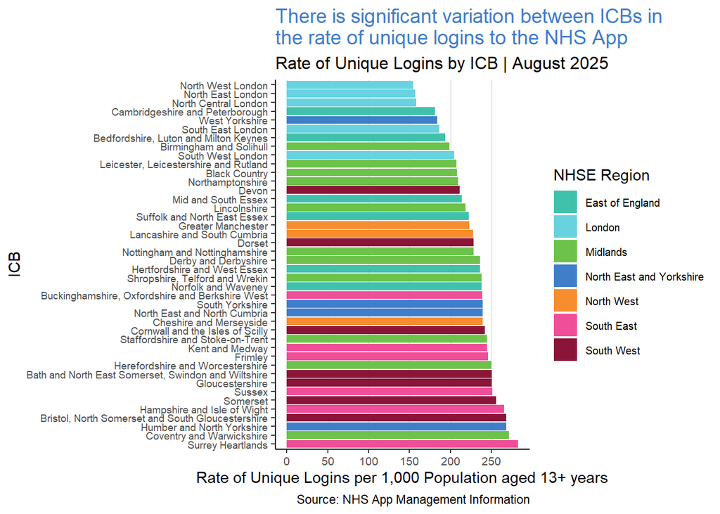

However, there is no publicly available information to help explain the differences between these rates or why we see this degree of regional variation. What are some of the population demographic factors that could be impacting use of the NHS App? How can we be confident that those using the NHS App are representative of the wider population or those who are using NHS services? Without understanding this how can we be confident that feedback on services will reflect the views and needs to those using them?

# Demographics Freedom of Information (FOI) Request

As there is no publicly available data on the demographics of users of the App we submitted an FOI request to NHS England to provide this demographic data.

## Our Request

We submitted an FOI to NHS England requesting the latest utilisation data for the App broken down by the following population demographics:

- **Age**: Age of the patient using the NHS App.
- **Gender**: Breakdown of the gender of patients using the NHS App.
- **Ethnicity**: Data on the ethnicity group of patients using the NHS App, broken down using the groupings within the NHS Data Dictionary or another appropriate grouping.
- **Deprivation**: The Index of Multiple Deprivation (IMD) decile for the user based on their resident postcode. If this wasn’t possible to use the IMD decile based on the GP Practice location.

## Data Provided and Caveats

NHS England were able to provide a breakdown of data for March, April and May 2025 for the following:

- **Age**: A breakdown of age into 5-year age bands. For the age band analysis, an initial band of age ‘13 to 14’ is presented, since users must be aged 13 or over to register with the NHS App. Users recorded as being aged 12 or younger have been included in the Unknown category.
- **Deprivation**: A breakdown by IMD deciles based on the user’s GP practice.

However, we were unable to obtain information relating to utilisation of the NHS App for gender and ethnicity. The FOI response stated that:

> *Information was also requested relating to the gender and ethnicity of NHS App users; however, this is not collected via NHS Login and so is not currently linked to NHS App login activity. Consequently, we are unable to provide login activity by gender and ethnicity of app users at this current time. We currently are working to expand our understanding of NHS App usage by linking to a wider range of demographic attributes and anticipate that we will have a more complete picture of activity by gender and ethnicity as we progress through winter 2025.*

Therefore, there remain unanswered questions about whether usage of the App is equitable across different genders and ethnic groups.

# FOI Analysis

## Age Group Analysis

We compared the rate of unique logins per 1,000 population for each of the age groups. To accurately estimate the population for each age group we used estimates from the [ONS](https://www.ons.gov.uk/peoplepopulationandcommunity/populationandmigration/populationestimates/bulletins/populationestimatesforenglandandwales/mid2023). This revealed for those accessing the NHS App in May 2025 there is significant variation in rates across different age groups.

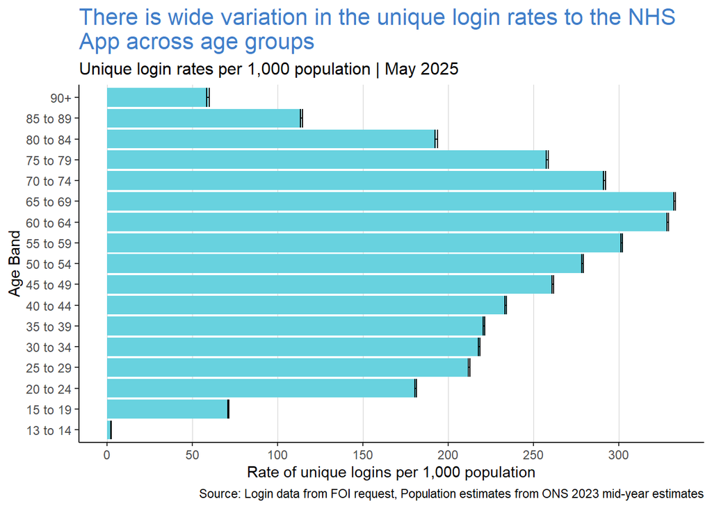

However, a better way to look at this would be to compare utilisation with the App to the utilisation of NHS services. This ensures that we consider if usage of the App is comparable to the usage of NHS services. This isn’t straight-forward though. How do we decide what an appropriate measure of the utilisation of NHS services is? Do we include all types of care activities? Does an admission equate to a GP appointment?

Looking at publicly available data we decided to use outpatient attendances by age group as a proxy for healthcare utilisation. We have used the latest available [annual publication on outpatient attendances](https://digital.nhs.uk/data-and-information/publications/statistical/hospital-outpatient-activity/2023-24), which covers the 2023/24 financial year.

Using this data it is possible to compare the proportion of logins by age group, with the proportion of outpatient appointments. The ratio of these two numbers determines if the number of logins to the App for that age group are proportionate to its share of the outpatient activity. For example, if 11% of all logins were for the 20-24 year old’s but they represent 15% of the outpatient appointments, then their ratio will be less than 1. This means this age-group would be underrepresented by those using the NHS App.

The charts below show the ratio of unique logins to outpatient attendances for those aged 15+. The vertical line at 1 is used to help identify age groups that are over or underrepresented.

**Note**

As the Outpatient Attendance data is only available in 5-year age bands we are unable to include the *13 to 14* age group from the NHS App login data.

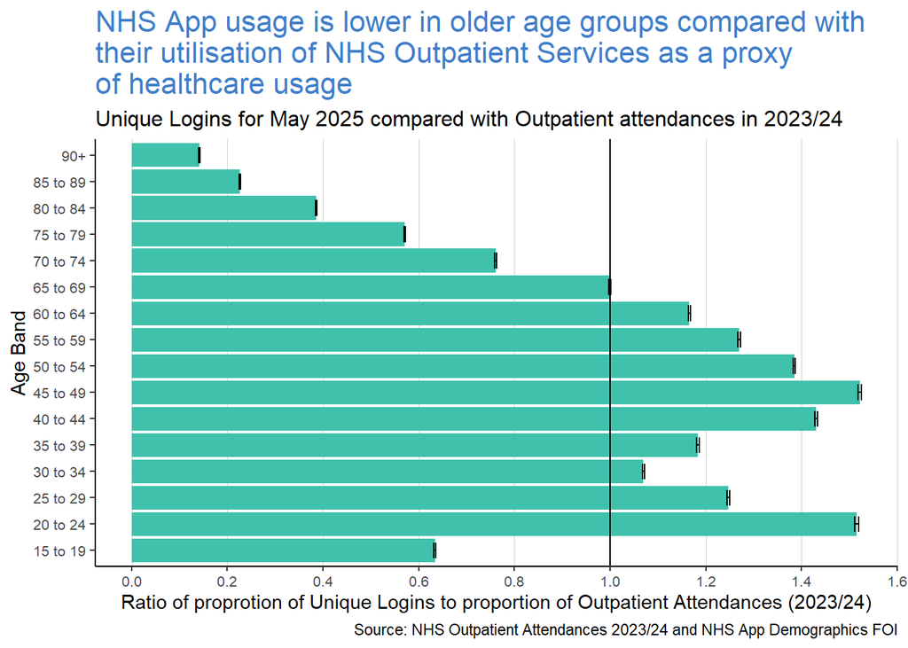

This chart clearly demonstrates that patients who are aged 70 years or older are **underrepresented** in using the NHS App when using outpatient attendances as a proxy for healthcare utilisation.

When comparing with ratio of the proportion of *total logins* rather than *unique logins* to the proportion of outpatient attendances we see a similar picture:

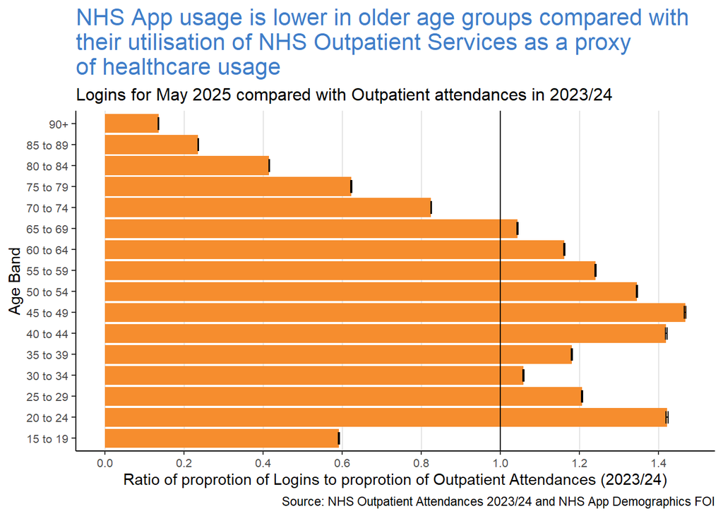

This under representation raises important questions about digital inclusion and the accessibility of NHS digital tools for older populations. If feedback collected through the App is to inform service improvements, it must reflect the experiences of all age groups, particularly those who are high users of NHS services as older populations often are.

## Deprivation Analysis

**Deprivation Deciles**

As part of the FOI we were also provided with login statistics broken down by IMD decile. However, this breakdown was not based on the decile **the patient was resident in** but on the decile based on the **location of their GP Practice**.

Looking at the rate of unique logins per 1,000 population across IMD Deciles showed that there is a higher utilisation of the NHS App within the more deprived areas. However, the variation seen across the deciles is much lower than across age groups.

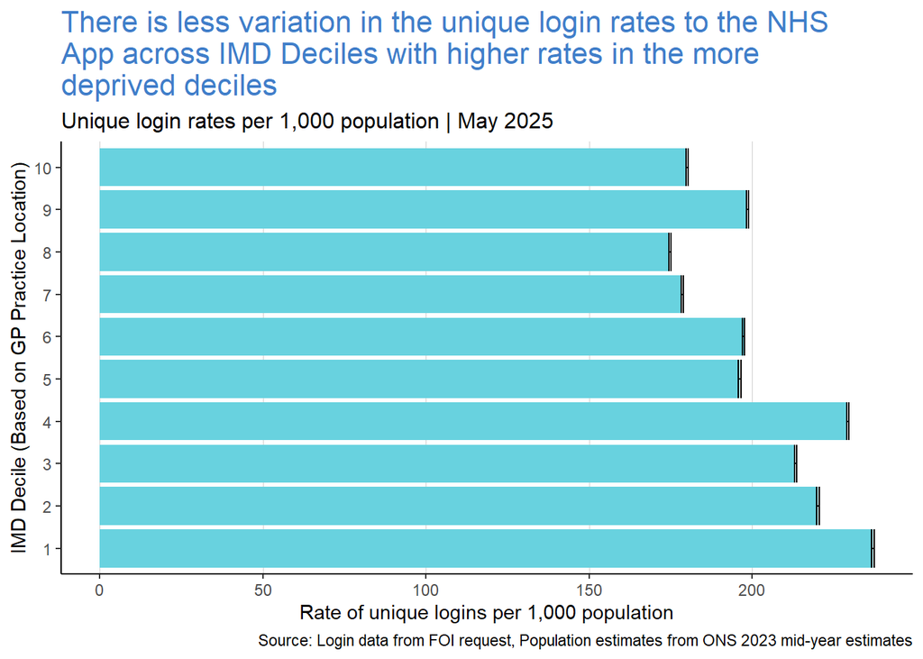

When we compare the ratio of unique logins to outpatient attendances, we see a similar picture of the more deprived areas having a higher than proportionate usage of the NHS App.

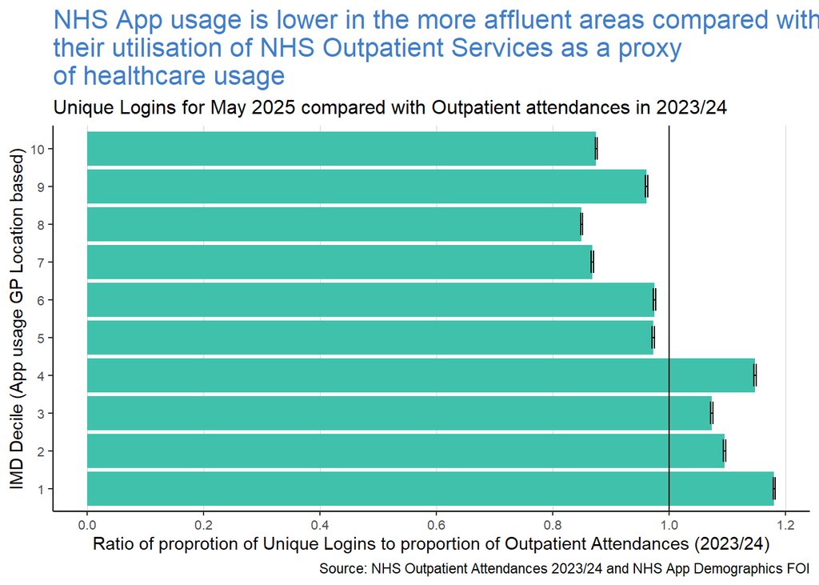

Interpreting this information is difficult, in part due to the caveat that deprivation is based on the location of the GP practice for App utilisation. As we are also analysing these two demographics in isolation we can’t answer if the lower rates of utilisation in the most affluent areas are being driven by lower rates amongst older patients. We know that the proportion of patients aged 65+ years across England is higher in more affluent areas but without more granular data this can’t be fully answered.

To fully understand patterns of digital engagement, and ensure feedback mechanisms are equitable, more detailed, linked demographic data is needed. Without it, there’s a risk that assumptions about who is using the App, and whose voices are being heard, may overlook key disparities shaped by the intersection of age, socioeconomic status, and access to care.

# Going forwards

This analysis raises critical questions for NHSE about the inclusivity and equity of digital feedback mechanisms. While the App offers a promising route for patients to share insights about their care, it is essential to ensure that feedback reflects the full diversity of service users. Without representative input, there is a risk that improvements will be shaped by the experiences of more digitally engaged groups, potentially widening existing health inequalities.

## Monitoring App Utilisation

Ensuring that there is a greater understanding of who is using the App is imperative. Whether this is through better data collection via the App or improved data linkage, this will need to happen as a priority. Understanding in more depth if the use of the App is representative of those who use NHS services is the first step to having the assurance feedback won’t be biased in favour of certain demographics.

NHS England did state in response to the FOI that:

> *We currently are working to expand our understanding of NHS App usage by linking to a wider range of demographic attributes and anticipate that we will have a more complete picture of activity by gender and ethnicity as we progress through winter 2025.*

Making as much of this data publicly available will also be important to provide the wider public with the confidence that the NHS is working to ensure that this is being monitored and acted on.

## Engaging with different groups

Since their creation in 2012, Healthwatch, both local and national, has gathered patient feedback on how NHS services are performing and understanding what matters to patients. Local Healthwatch organisations have a history of engaging with *seldom heard groups* to ensure that their views on health and care services aren’t ignored.

The 10-year plan also announced the abolition of Healthwatch England and local Healthwatch engagement functions becoming the responsibility of ICBs and providers. There is a risk that feedback on care from these groups via the NHS App isn’t aggregated together, and that these groups lose any collective voice. It is therefore imperative that ICBs and providers actively seek out and incorporate feedback from seldom-heard groups, particularly as digital tools become more central to patient engagement, so as to not further deepen existing gaps in healthcare experiences and outcomes between groups.

## Responsibility for App Engagement

The 10-year plan states that the NHS will:

> *We will also continue our current partnership with libraries and other community organisations to help set people up on the NHS App. We will continue recruiting App Ambassadors across the country to support uptake.*

[NHS App Ambassadors](https://digital.nhs.uk/services/nhs-app/become-an-nhs-app-ambassador) are advocates for the NHS App which can include delivering training individuals how to download and use the App. Recruitment of NHS App Ambassadors is currently the responsibility of NHS England. Given the abolition of NHS England, there remains the question of who has responsibility for this going forwards. Will this transition to the Department for Health and Social Care or become the responsibility of local care organisations? Wherever this responsibility is eventually placed, it will be vital that outreach strategies are maintained and strengthened, especially in communities facing digital exclusion. Local teams and ambassadors must be equipped with data on usage patterns to target support effectively and ensure equitable access.

## Building digital trust

Beyond access and representation, a critical but often overlooked dimension of health inequality is digital trust i.e. the extent to which individuals feel confident using digital tools to manage their health and share personal information. For many patients, particularly those from ethnic minority backgrounds, older adults, or those where English is not their first language, the App may not feel like a safe or intuitive space. Concerns about data privacy, unfamiliarity with digital interfaces, and past negative experiences with healthcare services can all contribute to reluctance or disengagement.

To truly democratise digital feedback, the NHS must invest not only in outreach as described above, but also in building trust through co-design. This means involving patients from diverse backgrounds in the development and refinement of App features, ensuring that accessibility and cultural relevance are embedded from the outset. It also means being transparent about how feedback is used, and demonstrating that patient voices, especially those from marginalised groups, lead to tangible improvements in care.

Without this trust-building, digital tools like the App risk becoming another layer of exclusion. The shift to using the App for patient feedback should not be a mechanism for passive data collection but should grasp the opportunity for the NHS to actively relationship-build with the communities it serves.

# Metadata

As part of our commitment to transparency in our work all of the data and code that is used to create this analysis is available from the associated [GitHub repository](https://github.com/NHS-Transformation-Unit/nhs_app_utilisation). This includes specific documentation on data sources saved within the `documentation` folder.